# Working with the Pokémon API

Michael Lightfoot | 06/26/22

## Required Packages

Below are the required packages to run this code:

- `tidyverse`
- `jsonlite`
- `ggplot2`
- `knitr`

## Contacting the API

We will define a few functions to help us contact the Pokémon API. In terms of endpoints, this API has many groups of them. Below are the groups with their respective endpoints:

- **Berries** - Berries, Berry Firmnesses, and Berry Flavors.
- **Contests** - Contest Types, Contest Effects, and Super Contest Effects
- **Encounters** - Encounter Methods, Encounter Conditions, and Encounter Condition Values.
- **Evolutiobn** - Evolution Chains Evolution Triggers
- **Games** - Generations, Pokedexes, Version, and Version Groups.
- **Items** - Item, Item Attributes, Item Categories, Item Fling Effects, and Item Pockets
- **Locations** - Locations, Location Areas, Pal Park Areas, and Regions.
- **Machines** - Machines
- **Moves** - Moves, Move Ailments, Move Battle Styles, Move Categories, Move Damage Classes, Move Learn Methods, and Move Targets
- **Pokémon** - Abilities, Characteristics, Egg Groups, Genders, Growth Rates, Natures, Pokeathlon Stats, Pokémon, Pokemon Location Areas, Pokemon Colors, Pokemon Forms, Pokemon Habitats, Pokemon Shapes, Stats, and Types
- **Utility** - Languages and Common Models

In my eyes, the **Pokémon** and **Moves** groups seem to have some interesting endpoints we should explore.

### `pokemonMoves`

```r
pokemonMoves <- function(pokemon, stats="all") {
  ###
  # This function returns a tibble of a given Pokémon's moves
  # and their names, type, power, accuracy and power points.
  ###

  #Even if ID or Name is given, the process for getting the data is the same
  data  <- fromJSON(paste0('https://pokeapi.co/api/v2/pokemon/',tolower(pokemon)))
  moves <- data$moves$move
  n     <- length(moves[,1])

  #Initialize output data.frame with a dummy row we will overwrite
  output <- data.frame(Name = "chr",
                       Type = "chr",
                       Power = 0,
                       Accuracy = 0,
                       PP = 0)

  #Loop through each move and grab desired variables for each move
  for (i in 1:n) {
    move    <- fromJSON(moves$url[i])
    #Initialize new row with dumm
    new     <- data.frame(Name = "chr",
                          Type = "chr",
                          Power = 0,
                          Accuracy = 0,
                          PP = 0)
    new[,1]  <- move$name
    new[,2]  <- move$type$name
    #Moves without a power will be given a power of 0 for the sake of this
    #analysis.
    if (length(move$power) == 0) {
      new[,3] <- 0
    } else {
      new[,3] <- move$power
    }
    #Moves with infinite accuracy will be given an accuracy score of 100
    #for the sake of this analysis.
    if (length(move$accuracy) == 0) {
      new[,4]   <- 100
    } else {
      new[,4]   <- move$accuracy
    }
    new[,5]     <- move$pp
    output[i,] <- new
  }

  #Now let's take into account the desired options
  if (stats == "all") {
    output <- as_tibble(output)
  }

  return(output)
}
```

## Exploratory Data Analysis

Now, let us use these functions to explore some of the data this API can give us. Let us call our first function, `pokemonMoves`, in order to explore the moves of the iconic Pokémon Squirtle.

```r
squirtleData <- pokemonMoves("squirtle")
```

Let’s look at the distribution of the different types of moves that Squirtle gets.

```r
kable(table(squirtleData$Type),"simple",
      col.names = c("Type", "Count"))
```

| Type | Count |
| --- | --- |
| dark | 2 |
| dragon | 2 |
| fighting | 9 |
| ghost | 1 |
| ground | 3 |
| ice | 7 |
| normal | 42 |
| poison | 1 |
| psychic | 5 |
| rock | 3 |
| steel | 3 |
| water | 21 |

Let’s use a plot to help us visualize this a bit better, including a color manual that utilizes the accepted colors for each type.

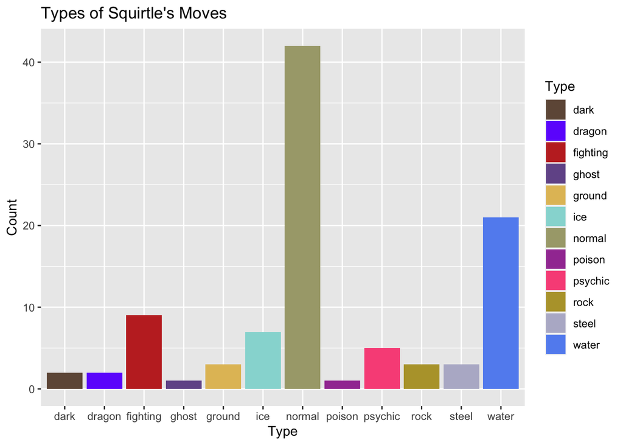

```r
manual <- c("normal"   = "#A8A77A",
            "fire"     = "#EE8130",
            "water"    = "#6390F0",
            "electric" = "#F7D02C",
            "grass"    = "#7AC74C",
            "ice"      = "#96D9D6",
            "fighting" = "#C22E28",
            "poison"   = "#A33EA1",
            "ground"   = "#E2BF65",
            "flying"   = "#A98FF3",
            "psychic"  = "#F95587",
            "bug"      = "#A6B91A",
            "rock"     = "#B6A136",
            "ghost"    = "#735797",
            "dragon"   = "#6F35FC",
            "dark"     = "#705746",
            "steel"    = "#B7B7CE",
            "fairy"    = "#D685AD")

squirtleData$Type <- as.factor(squirtleData$Type)
plot1 <- ggplot(squirtleData, aes(x=Type, fill=Type)) +
  geom_bar() +
  labs(title = "Types of Squirtle's Moves", y = "Count") +
  scale_fill_manual(values = manual)
plot1
```

It looks like most of Squirtle’s moves are either Normal or Water Type. That makes sense, considering Squirtle is a Water Type Pokémon!

It would be nice to take a look at the different powers of moves within each type. However, there are many different possibilities for the power of a move. Let’s define some categories for the different strengths of moves:

- *Status*: Power is 0 - these moves have some alternate effect.
- *Weak*: 0 $<$ Power $\leq$ 50
- *Decent*: 50 $<$ Power $\leq$ 80
- *Strong*: Power $>$ 80

Let’s add a variable called Strength that categorizes the Power variable into these groups.

```r
squirtleData$Strength <-
  ifelse(squirtleData$Power == 0,"Status",
         ifelse(squirtleData$Power <= 50, "Weak",
                ifelse(squirtleData$Power <= 80, "Decent","Strong")))
squirtleData$Strength <- as.factor(squirtleData$Strength)
squirtleData$Strength <- ordered(squirtleData$Strength,
                                 levels = c("Status",
                                            "Weak",
                                            "Decent",
                                            "Strong"))
```

With this new variable, let’s look at the distributions of different types of Squirtle’s moves within these categories.

```r
kable(table(squirtleData$Strength,squirtleData$Type), "simple")
```

|  | dark | dragon | fighting | ghost | ground | ice | normal | poison | psychic | rock | steel | water |
| --- | --- | --- | --- | --- | --- | --- | --- | --- | --- | --- | --- | --- |
| Status | 1 | 0 | 2 | 1 | 1 | 3 | 23 | 1 | 3 | 0 | 2 | 4 |
| Weak | 0 | 0 | 2 | 0 | 1 | 0 | 7 | 0 | 1 | 1 | 0 | 4 |
| Decent | 1 | 0 | 3 | 0 | 1 | 2 | 7 | 0 | 1 | 2 | 0 | 8 |
| Strong | 0 | 2 | 2 | 0 | 0 | 2 | 5 | 0 | 0 | 0 | 1 | 5 |

Again, let’s take a visual look at distributions, with the color representing Strength this time.

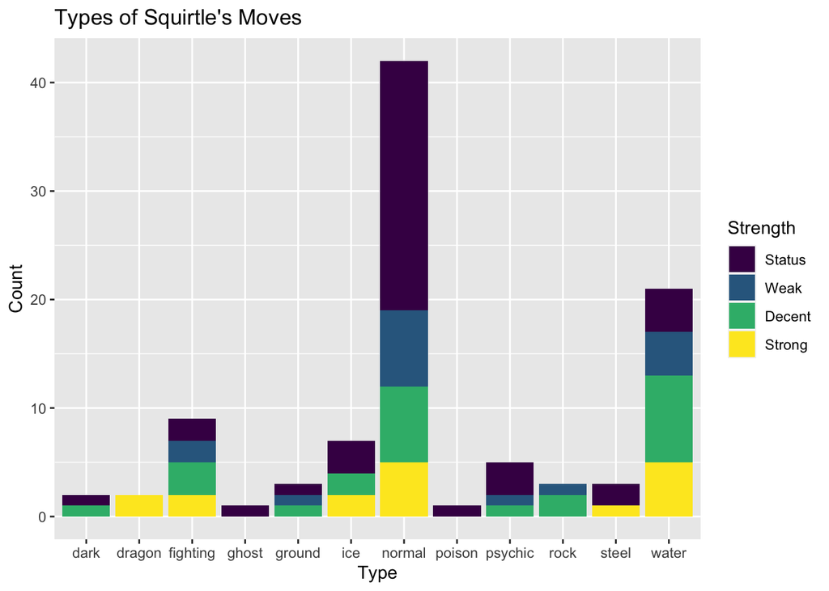

```r
plot2 <- ggplot(squirtleData, aes(x=Type, fill=Strength)) +
  geom_bar() +
  labs(title = "Types of Squirtle's Moves", y = "Count")
plot2
```

It looks like a major reason Squirtle has so many Normal Type moves is because so many Status moves seem to be Normal Type.

Since we discuss the Power variable heavily from this point on, let’s remove moves from the Status category for the remainder of our analysis, as these moves all have a Power of zero.

```r
squirtleData <- squirtleData %>%
  filter(squirtleData$Strength != "Status")
```

With this done, let’s look at a few numerical summaries of the Power variable within the remaining Strength categories.

```r
table1 <- squirtleData %>%
  group_by(Strength) %>%
  summarise(Mean = round(mean(Power)),
            Median = round(median(Power)),
            SD = round(sd(Power)))
kable(table1, "simple")
```

| Strength | Mean | Median | SD |
| --- | --- | --- | --- |
| Weak | 39 | 40 | 9 |
| Decent | 71 | 75 | 9 |
| Strong | 108 | 100 | 21 |

Now that we have an idea about the power of Squirtle’s moves, let’s incorporate the accuracy of Squirtle’s moves into this discussion. First, let’s plot the Power of Squirtle’s moves versus their Accuracy.

[figure not shown]

```r
plot3 <- ggplot(squirtleData, aes(x=Accuracy, y=Power, color=Type, label=Name)) +
  geom_point(position="jitter") +
  labs(title = "Power vs Accuracy of Squirtle's Moves") +
  scale_color_manual(values = manual)
plot3
```

However, this is not the whole story. In Pokémon, there is a mechanic called **Same Type Attack Bonus**, or **STAB** for short. This increases the effective power of moves that match a Pokémon’s type by 50%. So, Squirtle’s Water Type moves technically should deal 50% more damage. Let’s define a new variable to represent the **Effective Power** of Squirtle’s moves.

```r
squirtleData$effPower <-
  ifelse(squirtleData$Type == "water",
         squirtleData$Power*1.5,
         squirtleData$Power)
```

With this in mind, let us re-examine this plot of Power versus Accuracy of Squirtle’s moves by using this new variable.

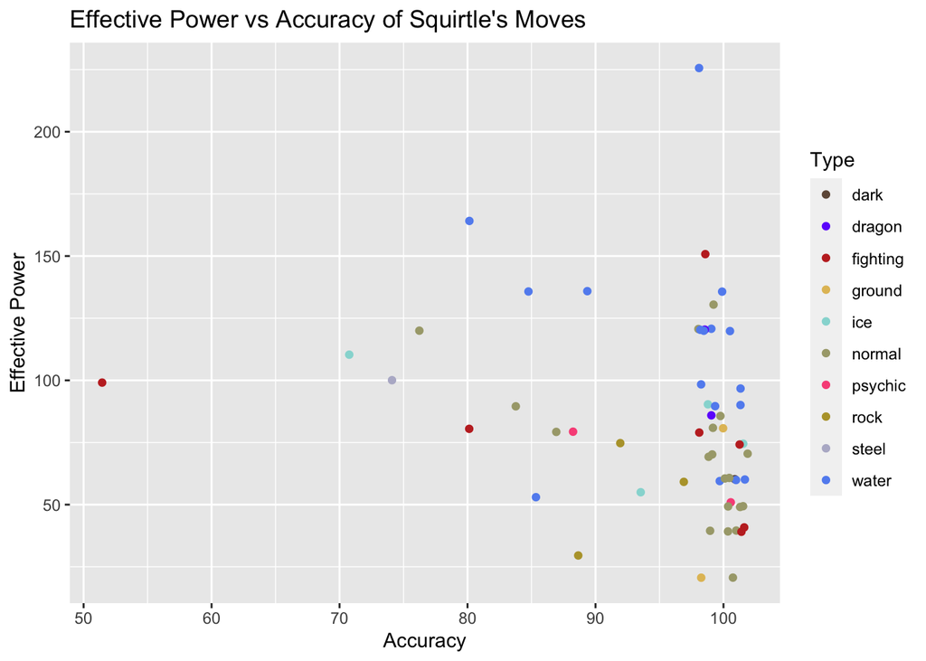

```r
plot4 <- ggplot(squirtleData, aes(x=Accuracy, y=effPower, color=Type, label=Name)) +
  geom_point(position="jitter") +
  labs(title = "Effective Power vs Accuracy of Squirtle's Moves", y = "Effective Power") +
  scale_color_manual(values = manual)
plot4
```

Now we can see some definite outlying Water Type moves by taking into account Squirtle’s **STAB**.

We can create another categorical variable called **Risk** that splits up Accuracy into the following groups:

- *No Risk*: Accuracy is 100
- *Low Risk*: 80 $\leq$ Accuracy $<$ 100
- *High Risk*: Accuracy $<$ 80

```r
squirtleData$Risk <-
  ifelse(squirtleData$Accuracy == 100,"No Risk",
         ifelse(squirtleData$Accuracy >= 80, "Low Risk","High Risk"))
squirtleData$Risk <- as.factor(squirtleData$Risk)
squirtleData$Risk <- ordered(squirtleData$Risk,
                                 levels = c("No Risk",
                                            "Low Risk",
                                            "High Risk"))
```

Let’s look at the distribution of the different Strengths of moves within these Risk categories.

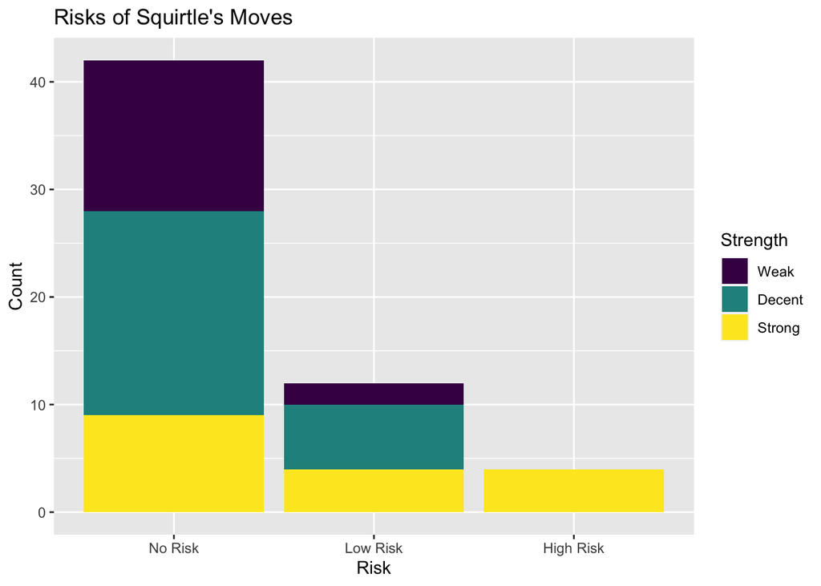

```r
plot5 <- ggplot(squirtleData, aes(x=Risk, fill=Strength)) +
  geom_bar() +
  labs(title = "Risks of Squirtle's Moves", y = "Count")
plot5
```

This distribution of the Strength levels within the different Risk categories makes a fair bit of sense. The risky moves are generally strong, while the weak and decent moves are generally less risky. Let’s look at some numerical summaries of Power within these Risk categories.

```r
table2<- squirtleData %>%
  group_by(Risk) %>%
  summarise(Mean = round(mean(Power)),
            Median = round(median(Power)),
            SD = round(sd(Power)))
kable(table2,"simple")
```

| Risk | Mean | Median | SD |
| --- | --- | --- | --- |
| No Risk | 70 | 68 | 30 |
| Low Risk | 73 | 80 | 24 |
| High Risk | 108 | 105 | 10 |

Now we can clearly see the High Risk moves have a much higher average Power.

Let’s quantify this a little bit and see if we can find Squirtle’s *best* move while taking into account both Power and Accuracy. If Squirtle were to use a move with an Accuracy of 90%, then 10% of the time the move will miss and therefore have an Effective Power of zero in that case. So, the **True Power** of a move would be the overall average of it’s possible Effective Power values. Let’s define a variable to represent this.

$$\text{True Power} = \text{Effective Power} \times \frac{\text{Accuracy}}{100}$$

```r
squirtleData$truePower <- squirtleData$effPower*squirtleData$Accuracy/100
```

With this variable defined, let’s try to find Squirtle’s top ten moves, ranked by their True Power.

```r
squirtleData <- squirtleData %>%
  arrange(desc(truePower)) %>%
  select(Name, Type, Power, Accuracy, truePower)

kable(head(squirtleData, n=10), "simple",
      col.names = c("Name", "Type", "Power", "Accuracy", "True Power"))
```

| Name | Type | Power | Accuracy | True Power |
| --- | --- | --- | --- | --- |
| water-spout | water | 150 | 100 | 225.0 |
| focus-punch | fighting | 150 | 100 | 150.0 |
| surf | water | 90 | 100 | 135.0 |
| hydro-pump | water | 110 | 80 | 132.0 |
| skull-bash | normal | 130 | 100 | 130.0 |
| aqua-tail | water | 90 | 90 | 121.5 |
| double-edge | normal | 120 | 100 | 120.0 |
| waterfall | water | 80 | 100 | 120.0 |
| outrage | dragon | 120 | 100 | 120.0 |
| dive | water | 80 | 100 | 120.0 |

From this table it seems **Water Spout** is Squirtle’s *strongest* move with a True Power of 225!

## Conclusion

Of course, there are many factors not being taken into account in this analysis. For example, Water Spout becomes a weaker move if Squirtle is at lower HP. Additionally, we did not take into account the defending Pokémon’s typing, which could affect the damage output. We did not take into account the differences between the Physical and Special categories of moves within Pokémon, and how that might affect damage output. We did not take into account additional effects of Squirtle’s moves, which would add a layer of subjectivity to this analysis. There are many ways to make our analysis more thorough, but I think this was a fun start!

Thank you for coming along on this journey with me! I hope you enjoyed taking a small dive into the Pokémon API.